# CRIM 545 Final Project: City of Fairfax Analysis

Raneem Sayyad

14 December 2025

# Executive Summary

This project analyzes larceny calls for service in the City of Fairfax from 2007 to 2025 to identify temporal and spatial patterns. Using historical data and a neural network forecast, the analysis explores where and when larceny hotspots occur and how they may change over different time periods, revealing trends and areas of higher risk.

How do daily larceny calls in the City of Fairfax, VA, vary over time and location, and what trends can be forecasted for 2026?

# Data

The data for this project comes from the City of Fairfax Police Department’s calls for service records, spanning 2007 to 2025 and including 395,657 individual records. For this analysis, I filtered the dataset to include only larceny-related calls, resulting in 10,623 records. These incidents were aggregated by day to calculate the number of larceny crimes per day. This daily aggregation supports both trend analysis and forecasting for future larceny activity. The data includes variables such as date, time, type of call, and location, which allows for temporal and spatial analysis of larceny patterns. By focusing on larceny, the analysis provides insight into where and when these crimes occur in Fairfax.

# Methods

To forecast future larceny calls, a univariate neural network model was developed using historical daily call counts as input. The model learns patterns and trends from past data to predict future activity. Time series forecasting tools in R were used to train the model and generate daily predictions for the entirety of 2026. The forecasted data was then filtered to include only 2026 and summarized by month to produce a clear view of expected monthly larceny activity. This approach allows for both trend visualization and temporal analysis. Additionally, the data was used to create spatial and temporal visualizations, including heatmaps and hotspot maps, to explore where and when larceny calls are most common.

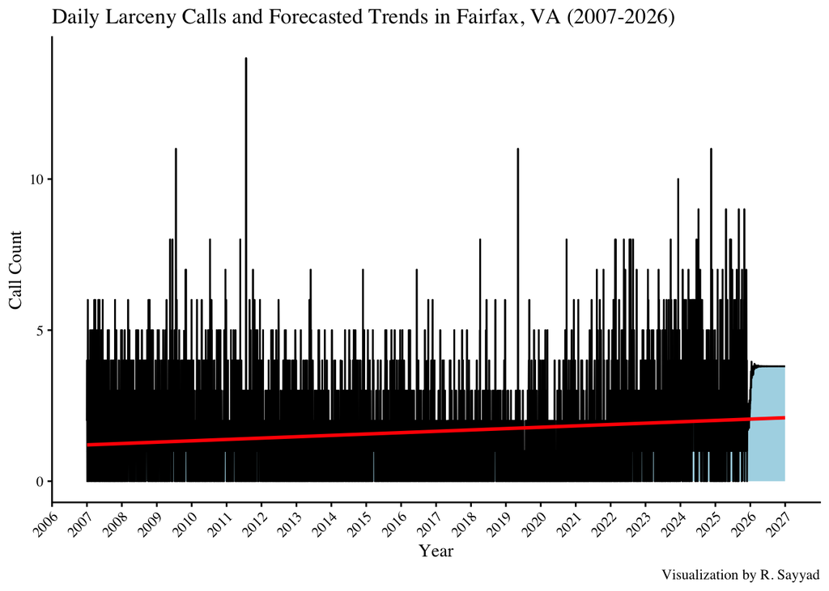